# Mid Term Project - Memo

February 25, 2019

##### **Date: February 25, 2019**

##### **RE: General Mills - A Study on Promo and Ad Effectiveness**

**Problem and desired solution**: In-store promos and ads had been run throughout the year and there was a need to understand how effective they are at driving improved product performance. This is important as performance of most products declined in Q2 and Q3 but improved in Q4.

**Data available**: We had available a sample of weekly store sales with data indicating when promos and/or ads(large or medium/small) were run. This data contained units sold, price, volume, packaging and flavor. Product information, with name of producer, was provided separately. We only know that promos involved a discount of greater than 5%, but not the exact percentage of discounts.

**Conclusions**: Promos and ads are effective in increasing demand (in terms of units sold) for our products, especially when run together. However, discounts offered via promos are cutting into margins and hence we should review the level of discounting offered.

I think the following points support the conclusions that I have drawn:

#### **Conclusion 1**: *Promos are effective in increasing demand for our products*

Key points:

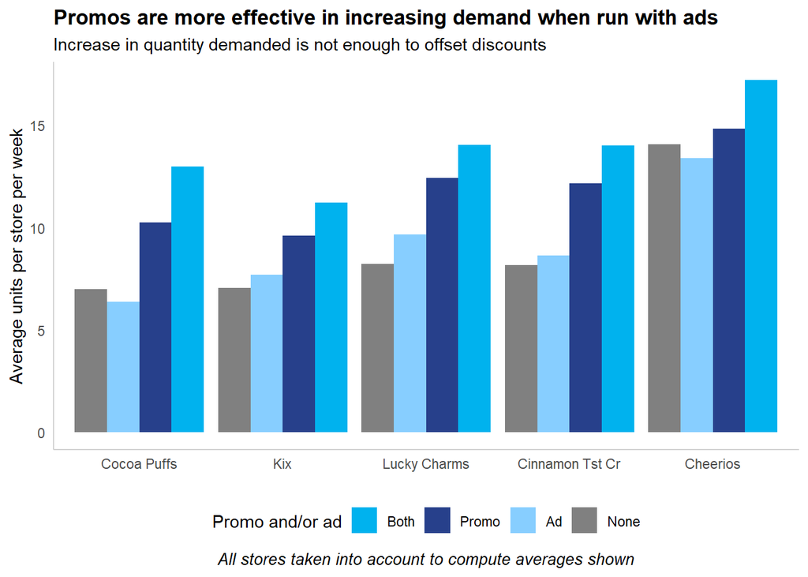

We have conducted statistical tests to confirm if running promos or ads makes a material difference to quantity demanded, and found enough evidence that in-store promos and ads are effective in increasing demand.

#### **Conclusion 2**: *We are losing revenue on Cheerios, our most popular product, when we run promos*

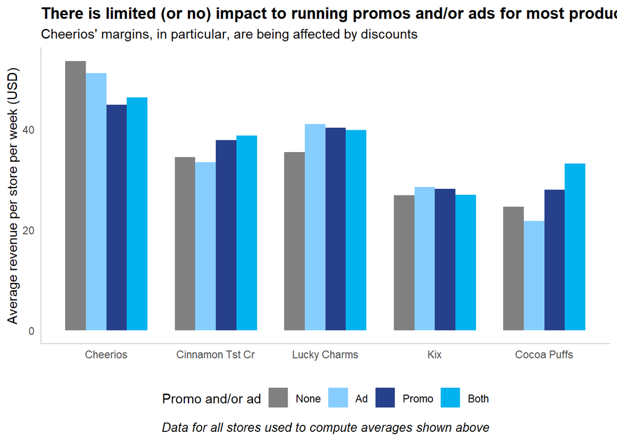

Key points:

- All products made more money on average (per week per store) when promos were run
- The exception is Cheerios
  - In fact, running promos without ads is particularly problematic
- This might mean one of two things:
  - Discounts were high (again, we do not know how much discount was offered) and/or
  - Demand didn’t increase by a larger percentage than the discount offered

We have run similar statistical tests to confirm this, and we do not have enough evidence to show that promos or ads helped increase revenue.

Based on the above two findings, we should review the level of discounts offered via promos, esp for Cheerios, as it may cut into margins even if demand is increased.

We would be happy to review this analysis in further detail, with you, in case you have any further questions.

Best,

Sourabh Gupta